# Modelling Day Project Parameter Exploration (example with binary model)

Mo Yin

26/10/2018

Step 1: Store functions required

Step 2: List parameters, the probability density functions from which the parameter values will be calculated, and what are the arguments to these functions

```r
factors <- c(             #list parameters in an array
    "n.bed",              #number of beds in the ward
    #"n.days",             #number of days of observation
    "mean.max.los",       #mean of length of stay (normal distribution)
    "p.s",                #probability of being prescribed narrow spectrum antibiotic
    "p.r",                #probability of being prescribed broad spectrum antibiotic
    "prob_StartBact_R",   #probability of initial carriage of resistant organisms
    "pi_r1",              #probability of being transmitted r to S (S—> Sr)
    "pi_r2",              #probability of being transmitted r to s (s—>sr)
    "mu1",                #probability of being decolonised to S (Sr—> S)
    "mu2",                #probability of being decolonised to S (sr—> s)
    "abx.r",              #probability of clearing R to become r
    "abx.s",              #probability of clearing S to become s
    "repop.r1",           #probability of transmission of r to S (s—> Sr)
    "repop.r2",           #probability of regrowth of s (sR—> sr)
    "repop.s1",           #probability of regrowth of S  (s—>S)
    "repop.s2",           #probability of regrowth of S  (sr—>Sr)
    "repop.s3",           #probability of transmission of r to S (s—> Sr)
    #"bif",               #bacterial interference factor (pi_r2 = pi_r1 * bif )
    #"bif1",              #bacterial interference factor 1 (repop.r3=repop.r2*bif1)
    "short_dur",          #mean short duration of antibiotics (normal distribution)
    "long_dur"            #mean long duration of antibiotics (normal distribution)
)
q <- c(                   #distributions of parameters
    "qunif",              # "n.bed", number of beds in the ward
    #"qunif",              # "n.days" number of days of observation
    "qunif",              # "mean.max.los", mean of length of stay (normal distribution)
    "qunif",              # "p.s", probability of being prescribed narrow spectrum antibiotic
    "qunif",              # "p.r", probability of being prescribed broad spectrum antibiotic
    "qunif",              # "prob_StartBact_R",probability of initial carriage of resistant organisms
    "qunif",              # "pi_r1" probability of being transmitted r to S (S—> Sr)
    "qunif",              # "pi_r2",probability of being transmitted r to s (s—>sr)
    "qunif",              # "mu1" probability of being decolonised to S (Sr—> S)
    "qunif",              # "mu2",probability of being decolonised to S (sr—> s)
    "qunif",              # "abx.r", probability of clearing R to become r
    "qunif",              # "abx.s", probability of clearing S to become s
    "qunif",              # "repop.r1", probability of transmission of r to S (s—> Sr)
    "qunif",              # "repop.r2", probability of regrowth of s (sR—> sr)
    "qunif",              # "repop.s1", probability of regrowth of S  (s—>S)
    "qunif",              # "repop.s2", probability of regrowth of S  (sr—>Sr)
    "qunif",              # "repop.s3",probability of transmission of r to S (s—> Sr)
    "qunif",              #"short_dur", mean short duration of antibiotics (normal distribution)
    "qunif"               #"long_dur", mean long duration of antibiotics (normal distribution)
)

q.arg <- list(            #set limits of parameters
    list(min=10, max=40),                # "n.bed", number of beds in the ward
    #list(min=10, max=20),                # "n.days" number of days of observation
    list(min=5, max=15),                 # "mean.max.los", mean of length of stay (normal distribution)
    list(min=0.1, max=0.9),              # "p.s", probability of being prescribed narrow spectrum antibiotic
    list(min=0.01, max=0.05),              # "p.r", probability of being prescribed broad spectrum antibiotic
    list(min=0.1, max=0.7),              # "prob_StartBact_R",probability of initial carriage of resistant organisms
    list(min=0.003, max=0.1),              # "pi_r1" probability of being transmitted r to S (S—> Sr)
    list(min=0.03, max=0.9),              # "pi_r2",probability of being transmitted r to s (s—>sr)
    list(min=0, max=0.5),              # "mu1" probability of being decolonised to S (Sr—> S)
    list(min=0, max=0.001),              # "mu2",probability of being decolonised to S (sr—> s)
    list(min=0.2, max=0.9),              # "abx.r", probability of clearing R to become r
    list(min=0.2, max=0.9),              # "abx.s", probability of clearing S to become s
    list(min=0, max=0.9),              # "repop.r1", probability of transmission of r to S (s—> Sr)
    list(min=0, max=0.3),              # "repop.r2", probability of regrowth of s (sR—> sr)
    list(min=0, max=0.001),              # "repop.s1", probability of regrowth of S  (s—>S)
    list(min=0, max=0.001),              # "repop.s2", probability of regrowth of S  (sr—>Sr)
    list(min=0, max=0.05),              # "repop.s3",probability of transmission of r to S (s—> Sr)
    list(min=4, max=10),                 #"short_dur", mean short duration of antibiotics (normal distribution)
    list(min=14, max=20)                 #"long_dur", mean long duration of antibiotics (normal distribution)
)
```

Step 3: Model

Model should be written such that

1. only parameters to be explored are arguments;
2. output of the model is/are the outcome(s)

```r
diff_prevalence <- function(n.bed, mean.max.los, p.s, p.r,
                            prob_StartBact_R, pi_r1, pi_r2, mu1, mu2, abx.r, abx.s,
                            repop.r1, repop.r2, repop.s1, repop.s2, repop.s3,
                            short_dur, long_dur){
    n.days=200
    iterations=10
    iter_totalsR <- matrix(NA, nrow = n.days, ncol = iterations)

    for(iter in 1:iterations){

        #print(paste("iter:", iter, "y:", y_count, '-', y, "x", x_count, '-', x))
        #Generate length of stay and antibiotic duration table
        abx_iter <- abx.table(n.bed=n.bed, mean.max.los=mean.max.los, p.s=p.s, p.r=p.r, meanDur=short_dur)
        #Generate baseline carriage status
        array_LOS_iter <- array_LOS_func(los_duration=abx_iter[[2]])
        #Update values for every day
        array_StartBact_iter <- gen_StartBact(los=array_LOS_iter, n.bed=n.bed, prob_StartBact_R=prob_StartBact_R)
        #output
        colo_table_filled_iter <- nextDay(bed_table= abx_iter[[1]], array_LOS=array_LOS_iter,
                                          treat_table=abx_iter[[3]], colo_table=array_StartBact_iter,
                                          pi_r1=pi_r1, pi_r2= pi_r2, mu1=mu1, mu2=mu2,
                                          abx.r=abx.r,abx.s=abx.s,
                                          repop.r1 = repop.r1, repop.r2 = repop.r2,
                                          repop.s1 = repop.s1, repop.s2 = repop.s2,repop.s3 = repop.s3)
        #Summary
        df <- data.frame(colo_table_filled_iter)
        iter_totalsR[, iter] <- rowSums(df == "sR")
        #print("end iteration loop")
    }
    totalsR_short <- mean(rowSums(iter_totalsR)/iterations/n.bed)

    iter_totalsR <- matrix(NA, nrow = n.days, ncol = iterations)
    for(iter in 1:iterations){

        #print(paste("iter:", iter, "y:", y_count, '-', y, "x", x_count, '-', x))
        #Generate length of stay and antibiotic duration table
        abx_iter <- abx.table(n.bed=n.bed, mean.max.los=mean.max.los, p.s=p.s, p.r=p.r, meanDur=long_dur)
        #Generate baseline carriage status
        array_LOS_iter <- array_LOS_func(los_duration=abx_iter[[2]])
        #Update values for every day
        array_StartBact_iter <- gen_StartBact(los=array_LOS_iter, n.bed=n.bed,prob_StartBact_R=prob_StartBact_R)
        #output
        colo_table_filled_iter <- nextDay(bed_table= abx_iter[[1]], array_LOS=array_LOS_iter,
                                          treat_table=abx_iter[[3]], colo_table=array_StartBact_iter,
                                          pi_r1=pi_r1, pi_r2= pi_r2, mu1=mu1, mu2=mu2,
                                          abx.r=abx.r,abx.s=abx.s,
                                          repop.r1 = repop.r1, repop.r2 = repop.r2,
                                          repop.s1 = repop.s1, repop.s2 = repop.s2, repop.s3 = repop.s3)
        #Summary
        df <- data.frame(colo_table_filled_iter)
        iter_totalsR[,iter] <- rowSums(df == "sR")
        #print("end iteration loop")
    }
    totalsR_long <- mean(rowSums(iter_totalsR)/iterations/n.bed)

    #print(paste("totalsR_long", totalsR_long, "totalsR_short", totalsR_short))

    return(totalsR_long - totalsR_short)
}
```

Step 4: Function to run the model across all combinations of parameters

```r
modelRun.binary <- function (data.df) { #data.df is a dataframe of the parameter values in columns
    return(mapply(diff_prevalence,
                  data.df[,1], data.df[,2], data.df[,3],
                  data.df[,4], data.df[,5], data.df[,6],
                  data.df[,7], data.df[,8], data.df[,9],
                  data.df[,10], data.df[,11], data.df[,12],
                  data.df[,13], data.df[,14], data.df[,15],
                  data.df[,16], data.df[,17], data.df[,18]
    ))
}
```

Step 5: Use the LHD function to generate a hypercube

Step 6: Plot findings

Plot 1: Empirical cumulative distribution function used to illustrate the distribution of the model results

Interpretation- most outcomes are in the steepest parts of the graph "

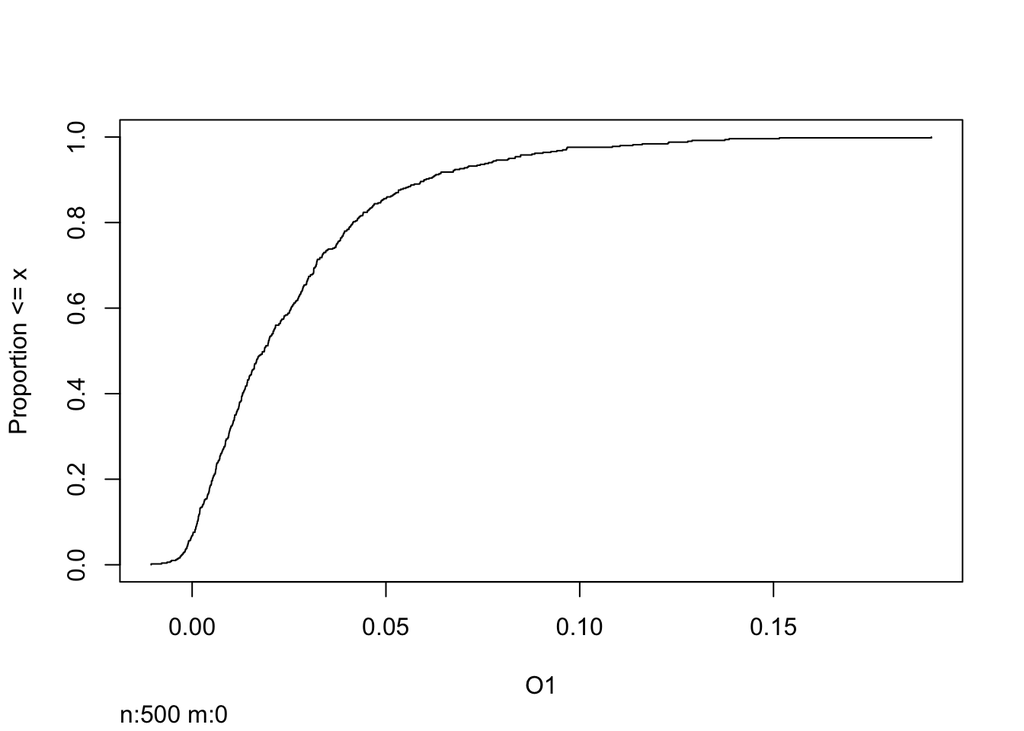

```r
plotecdf(LHS.binary)
```

Plot 2: Scatterplot of the result as a function of each parameter: distribution of values returned by the model in the parameter space sampled by the hypercube and how sensible are these model responses to the variation of each parameter.

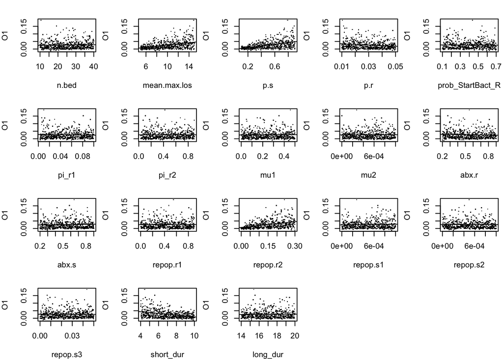

```r
plotscatter(LHS.binary)
```

Plot 3: Partial correlation coefficient measures how strong are the inear associations between the result and each input parameter, after removing the linear effect of the other parameters. CI generated by boostrapping.

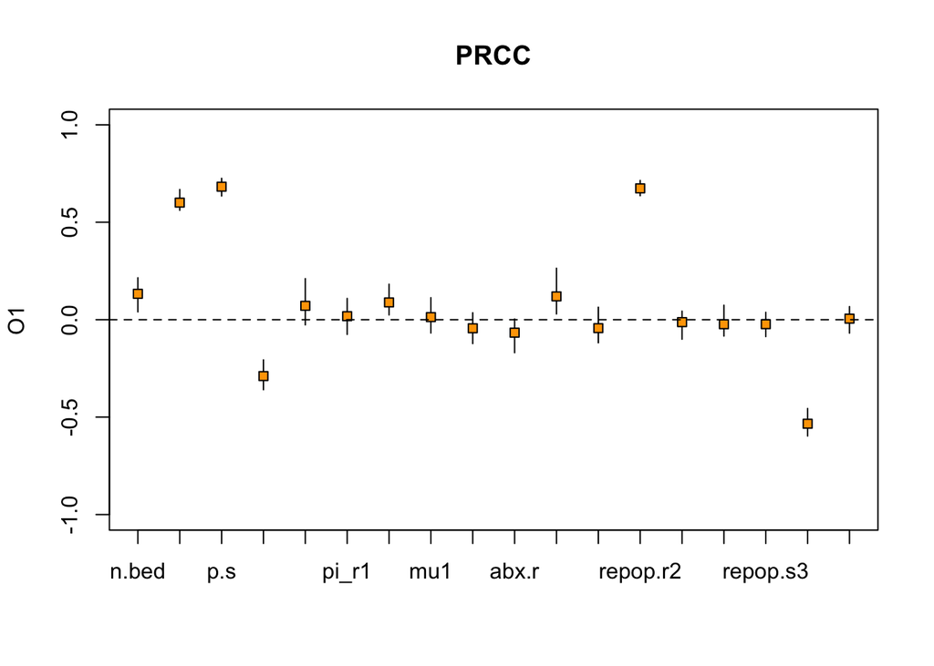

```r
plotprcc(LHS.binary)
```

PIC(partial inclination coefficient) is the sensitivity" of the model response in respect to each parameter represent the beta terms in y = alpha + beta*x regressions, after removing the linear effect of the other parameters.

```r
pic(LHS.binary, nboot=40)
```

```
## [[1]]
##
## Call:
## pic.default(X = L, y = r, nboot = nboot, conf = conf)
##
## Partial Inclination Coefficients (PIC):
##                       original          bias   std. error     min. c.i.
## n.bed             0.0001406761 -3.817273e-07 7.456742e-05 -0.0000223906
## mean.max.los      0.0038088503  1.983569e-05 2.798098e-04  0.0033124655
## p.s               0.0546220495  6.291245e-04 3.773298e-03  0.0454226245
## p.r              -0.4039129315  1.374795e-03 5.952743e-02 -0.5337035347
## prob_StartBact_R -0.0019181790  1.575234e-04 3.163962e-03 -0.0094025889
## pi_r1            -0.0495475170 -6.288723e-03 2.623556e-02 -0.0923561824
## pi_r2             0.0004622063  1.137863e-04 2.380686e-03 -0.0043336824
## mu1               0.0034051722  8.995776e-04 4.422582e-03 -0.0067445857
## mu2               0.8808292269 -4.693398e-01 2.729290e+00 -4.6162138683
## abx.r            -0.0075016801 -7.476181e-04 2.855289e-03 -0.0143090148
## abx.s             0.0070915015  4.381217e-04 3.027480e-03 -0.0005309111
## repop.r1          0.0004302217  1.422273e-04 2.413163e-03 -0.0041114450
## repop.r2          0.1266525284  4.283169e-04 8.328535e-03  0.1114765387
## repop.s1          4.3755892196  3.118356e-01 2.408653e+00 -1.2376364060
## repop.s2         -0.3239915129  5.010520e-02 2.459614e+00 -5.2967107498
## repop.s3         -0.0172016261 -1.372453e-04 4.797702e-02 -0.1089695061
## short_dur        -0.0057352343 -2.993572e-05 4.375224e-04 -0.0066429817
## long_dur          0.0003405285  3.491615e-05 3.569241e-04 -0.0005353128
##                      max. c.i.
## n.bed             0.0003064237
## mean.max.los      0.0043623871
## p.s               0.0637490391
## p.r              -0.2953899851
## prob_StartBact_R  0.0050154098
## pi_r1             0.0030110748
## pi_r2             0.0065032457
## mu1               0.0151113572
## mu2               6.9918509410
## abx.r            -0.0008704350
## abx.s             0.0122746474
## repop.r1          0.0048726595
## repop.r2          0.1456402602
## repop.s1          9.6124713125
## repop.s2          5.2198868261
## repop.s3          0.1212664991
## short_dur        -0.0045867782
## long_dur          0.0011450988
```

Plot 4: Cobweb

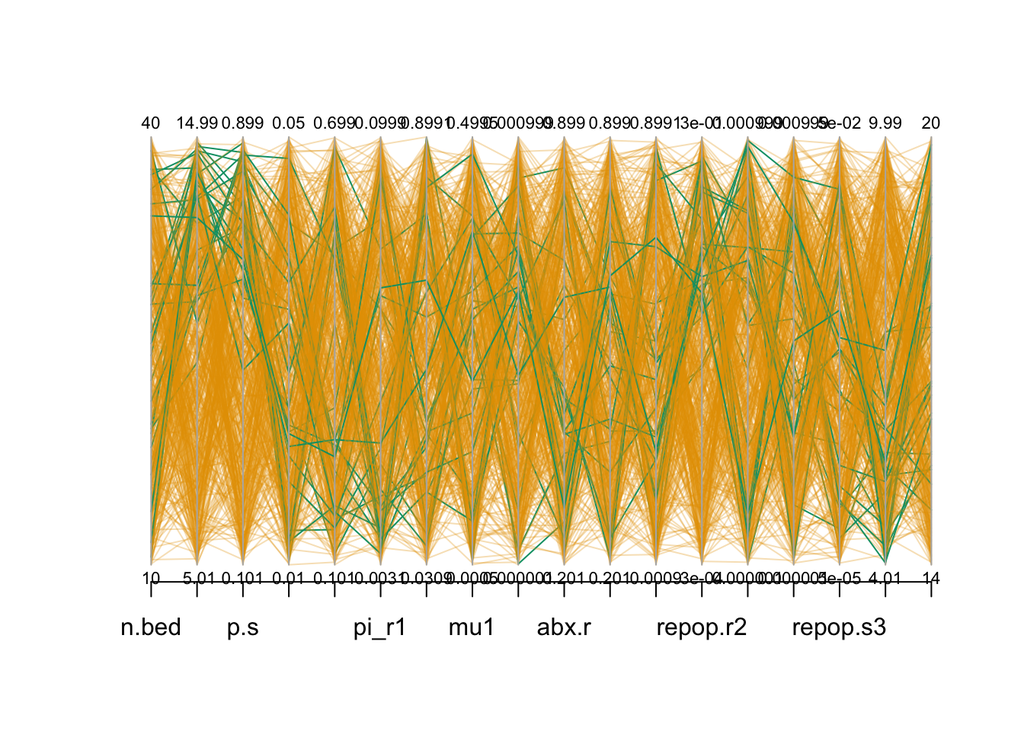

```r
for (i in 1:nrow(outcome.df)) {       #label the rows of parameter values that produced top 5% of the outcomes
    if (outcome.df$outcome[i]<quantile(outcome.df$outcome,probs = 0.95)) {
        outcome.df$top5[i] <-0 } else {
            outcome.df$top5[i] <-1
        }
}
library(MASS) #load MASS package
colors<- c(alpha("#E69F00", alpha = 0.3), "#009E73") #choose 2 colors - 1 for parameters that produced top 5% of outcomes and one for the rest
outcome.df$top5<- as.factor(outcome.df$top5)
parcoord(outcome.df[,c(1:length(factors))] , col= colors[outcome.df$top5],var.label=T)
```

Step 7: Check agreement between runs to decide if our sample size for adequate

Symmetric Blest Measure of Agreement (SBMA) between the PRCC coeffients of two runs with different sample sizes.

Interpretation:

- value of -1 indicates complete disagreement between the runs
- value of 1 indicated complete agreement (>0.7 acceptable)

caveat: if none of the model parameters is monotonically correlated with the output, the agreement between runs may stay as low as 0.2 even for very large hypercubes.

```r
check.LHS.binary <- LHS(modelRun.binary, factors, 400, q, q.arg)
(mySbma <- sbma(LHS.binary, check.LHS.binary))
```

```
## [1] 0.5964369
```